# Exercise: Finish a program to fill a 2D array

The program image_creator.cpp draws on many of the C++ concepts that are taught in this lesson. It also introduces the way in which accelerated frameworks like OpenCL and HIP execute small functions called *kernels* over iteration spaces of up to three dimensions.

Within **main**, the program allocates an array `arr` of size (4x6). This array is one-dimensional, but it is accessed as if it was *folded* into a 2D array of size (N0=4, N1=6). The program used nested loops to iterate over the domain of `arr` and each coordinate (i0, i1) it executes a function called `fill_kernel` to fill the array with the value of i0xi1.

The problem is fairly straightforward and requires **only two lines of code**. However these two lines require a *firm grasp* of multi-dimensional array indexing in order to get it right. Within the function `fill_kernel` you need to use **row-major** ordering to fill `arr` at coordinates `(i0, i1)` with the value of `i0*i1`.

The supplied function `m_show_matrix` prints out the array to the command line and the program writes the resulting image to a file called `image.dat`. You are welcome to use these tools to help debug your code, and you can also use **std::printf**, **std::cout**, or the GNU debugger GDB.

## Steps

- Open image_creator.cpp and have a look to see what the file is doing.
- Open a terminal and use **cd** to navigate to the **L0_Survival_C++** directory.

```
cd course_material/L0_Survival_C++
```

- Type **make clean** and then **make** to make the program **image_creator.exe**. Notice that we changed the makefile to compile with flags "-g -O0". These flags enable extra support for debugging and turns off all optimisations that might hide code. We could also have compiled the source file directly by typing:

```
g++ -g -O0 image_creator.cpp -o image_creator.exe
```

- Run the program `./image_creator.exe` to verify that it produces an empty array of zeros.

```python
!./image_creator.exe
```

```
The computed solution (arr) is
------
|  0.00e+00  0.00e+00  0.00e+00  0.00e+00  0.00e+00  0.00e+00 |
|  0.00e+00  0.00e+00  0.00e+00  0.00e+00  0.00e+00  0.00e+00 |
|  0.00e+00  0.00e+00  0.00e+00  0.00e+00  0.00e+00  0.00e+00 |
|  0.00e+00  0.00e+00  0.00e+00  0.00e+00  0.00e+00  0.00e+00 |
------
```

- Make changes to `fill_kernel` to fill the allocation `arr` with the correct value and use `make` to recompile.
- Debug any issues with your code using print statements or the GNU debugger.
- Success is when your code doesn't crash, and produces the same output as `image_creator_answer.exe`.

```python
!./image_creator_answer.exe
```

```
The computed solution (arr) is
------
|  0.00e+00  0.00e+00  0.00e+00  0.00e+00  0.00e+00  0.00e+00 |
|  0.00e+00  1.00e+00  2.00e+00  3.00e+00  4.00e+00  5.00e+00 |
|  0.00e+00  2.00e+00  4.00e+00  6.00e+00  8.00e+00  1.00e+01 |
|  0.00e+00  3.00e+00  6.00e+00  9.00e+00  1.20e+01  1.50e+01 |
------
```

## Debugging

You can use either print statements or a debugger to find errors in your code.

### Debugging with print statements

You can use C or C++ style print statements to print variables during the execution of a program. This process can be laborious because you need to add and remove code from your program and recompile each time.

### Debugging with GDB

Print statements can be helpful, but a debugger is much more powerful. You can use a debugger to step through each line of the program and examine variables. Here is a mini-tutorial.

- Run the program with the GNU DeBugger (GDB) using the command

```
gdb ./image_creator.exe
```

or, if you have access to Setonix or other system with ROCM installed.

```
module load rocm/5.4.3
rocgdb ./image_creator.exe
```

- Now within gdb type `run` to start the program. It will execute until it crashes
- Set a breakpoint to stop at the `fill_kernel` function with the command

```
b fill_kernel
```

or you can stop anywhere by quoting a source file and line number, like this:

```
b image_creator.cpp:28
```

- Execute `run` again, it will run until it hits the breakpoint.
- Print the passed-in variables `N0` and `N1` with this command

```
print N0
print N1
```

In this way you can print variables and even print array values!

```
print A[0]
```

- Step through a few lines of code, press `n` and then `enter` a few times. Notice how the debugger is executing the `fill_kernel` function again and again from the inner i1 loop.
- You can use the `s` command to step into a function that is called. Then use `n` to walk over the lines in that function.
- The `c` command continues until the next breakpoint is encountered or the program exits.
- You can then execute `run` again to start the program from the beginning.
- When you are done, within **gdb** type `del` to remove all breakpoints and then type `quit` to quit the debugger.

## The solution if you get stuck

You can always peek at the solution image_creator_answer.cpp. The bugs are fixed, and it can be compiled with either **make** or

```
g++ -g -O0 -I../include image_creator_answer.cpp -o image_creator_answer.exe
```

```python
!make image_creator_answer.exe; ./image_creator_answer.exe
```

```
g++ -g -std=c++11 -O0 -I/usr/include -I../include -L/usr/lib/x86_64-linux-gnu image_creator_answer.cpp\
	-o image_creator_answer.exe
b interpreted as an integer: 116
b interpreted as a character: t
abcd
float representation, x = 5.000000 y = 6.000000
The computed solution (arr) is
------
|  0.00e+00  0.00e+00  0.00e+00  0.00e+00  0.00e+00  0.00e+00 |
|  0.00e+00  1.00e+00  2.00e+00  3.00e+00  4.00e+00  5.00e+00 |
|  0.00e+00  2.00e+00  4.00e+00  6.00e+00  8.00e+00  1.00e+01 |
|  0.00e+00  3.00e+00  6.00e+00  9.00e+00  1.20e+01  1.50e+01 |
------
```

## Display the image with Python

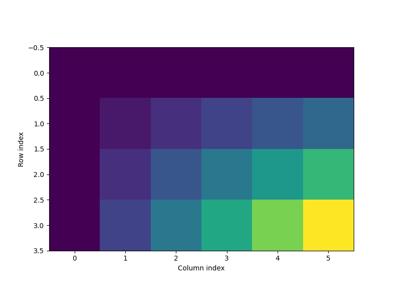

```python
# Get the size of the image
import numpy as np
from matplotlib import pyplot as plt

%matplotlib widget

# Read the size information from the header file
with open("mat_size.hpp") as fd:
    nrows = int(fd.readline().split()[2])
    ncols = int(fd.readline().split()[2])

# Read the binary image file
img = np.fromfile("image.dat", dtype=np.float32).reshape(nrows,ncols)

# Plot the image
[fig, ax] = plt.subplots(1, 1, figsize=(8, 6))
im2 = ax.imshow(
    img,
    aspect="equal",
    origin="upper",
)

# Set labels
ax.set_xlabel("Column index")
ax.set_ylabel("Row index")
```